# Prosper Loan Data Exploratory Analysis

## Introduction

Prosper Marketplace, Inc. is a San Francisco, California-based company in the peer-to-peer lending industry. This is a website where individuals can either invest in personal loans or request to borrow money.

This dataset contains 113937 loans with 81 variables on each loan, including loan listing details, borrower's creidt profile and lender's profile.

## Goal

In this work, it is of great interest to find out what variables influence a borrower's interest rate.

As a company, Prosper need to serve both borrower and lender. What are characteristics of defaulted or charged off loans? Is there any area Prosper could work on to improve Prosper product?

# Understand Prosper Product

### Loan Amount

The loan amount is between 1000 to 40000. The most popular loan amount is around 4000. There are very few case when loan amount is larger than 30000

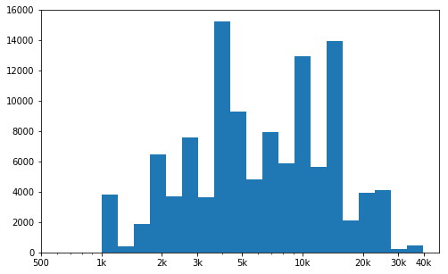

```python
log_binsize = 0.08
plt.figure(figsize=[8,5])
bc=sns.color_palette()[0]
bins = 10 ** np.arange(np.log10(1000), (np.log10(35000)+log_binsize), log_binsize)
plt.xscale('log')
plt.xticks([500, 1e3, 2e3,3e3, 5e3, 1e4, 2e4,3e4, 4e4], [500, '1k', '2k','3k', '5k', '10k', '20k', '30k','40k'])
plt.hist(data=loan_df_copy, x='LoanOriginalAmount',bins=bins)
plt.xscale('log')
_=plt.xticks([500, 1e3, 2e3,3e3, 5e3, 1e4, 2e4,3e4, 4e4], [500, '1k', '2k','3k', '5k', '10k', '20k', '30k','40k'])
```

### Loan Term

At prosper, 3 year loan term is most popular. This might be affected by combined interest rate and fee rate. One year might be too short to pay off loan while 5 year might have much higher interest rate.

```
Text(0,0.5,'')
```

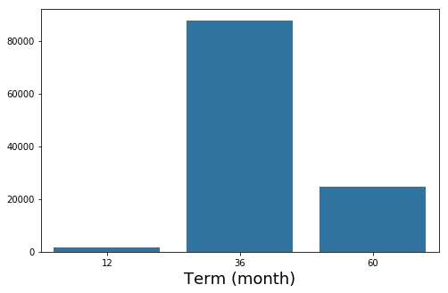

```python
plt.figure(figsize=[8,5])
sns.countplot(data=loan_df_copy, x='Term', color=sns.color_palette()[0])
plt.xlabel('Term (month)', fontsize=18)
plt.ylabel('')
```

### Borrower Interest Rate

Extremely low interest rate range 0-0.05% and high rate 0.35-0.5% are quite rare. The most typical rate is observed in the range of 0.1%-0.15%

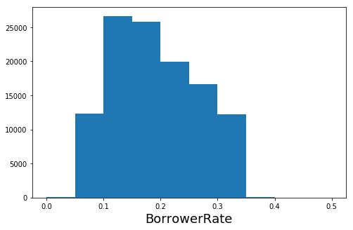

```python
# Explore input Credit's distribution
# Explore output BorrowerRate's distribution
# try to identify any pattern in this dataset
plt.figure(figsize=[8,5])
binsize=np.arange(0,0.5+0.03, 0.05)
plt.hist(data=loan_df_copy, x='BorrowerRate',bins=binsize)
_=plt.xlabel('BorrowerRate', fontsize=18)
```

### How is Prosper loan doing? How many loans are loss or gain?

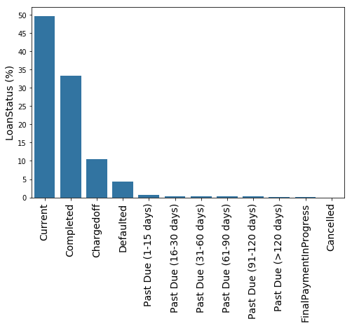

```python
plt.figure(figsize=[8,5])
sns.barplot(x='index', y='LoanStatus', data=LoanStatus_Per,color=bc)
plt.xticks(rotation=90, fontsize=14)
plt.yticks(np.arange(0, 50.5, 5))
plt.ylabel('LoanStatus (%)', fontsize=14)
_=plt.xlabel('')
```

### When people use Prosper loan most for?

- The most popular loan type is for debt consolidation among 21 classified categories. It has close to 60000 cases accounting for 51% of total loans.
- There are also 18000 loans without specifying loan purpose. It is interesting to find out that people seek Prosper loan to debt consolidation

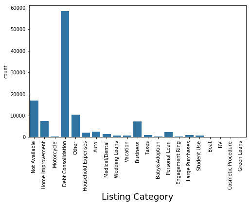

```python
plt.figure(figsize=[8,5])
sns.countplot(data=loan_df_copy, x='ListingCategory', color=bc)
plt.xlabel('Listing Category', fontsize=18)
_=plt.xticks(rotation=90)
```

# What factors impact on borrower interest rate?

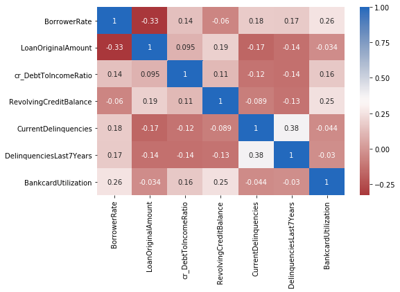

```python
plt.figure(figsize = [8, 5])
_=sns.heatmap(loan_df_copy[num_columns1].corr(), annot=True, cmap='vlag_r')
```

### Loan Amount

The higher loan amount tend to receive lower interest rate. This might be an incentive for borrower to loan more so that investor and Prosper could have higher profit when loan is completed.

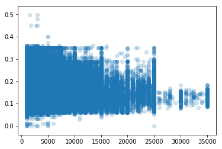

```python
_=plt.scatter(data=loan_df_copy, x='LoanOriginalAmount',y='BorrowerRate', alpha =0.2)
```

## Delinquency

When Current Deliquencies is larger than 10, it is more likely to get higher interest rate for Prosper loan

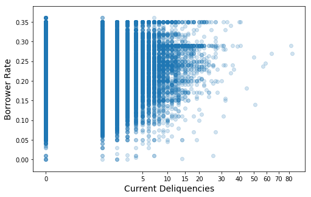

```python
plt.figure(figsize=[8,5])
plt.scatter(data=loan_df_copy, x='cr_CurrentDelinquencies',y='BorrowerRate', alpha =0.2)
deliquency_ticks=[0,5,10,15,20,30,40,50,60,70,80]
plt.xticks(cuberoot_trans(np.array(deliquency_ticks)), deliquency_ticks)
plt.xlabel('Current Deliquencies', fontsize=14)
plt.ylabel('Borrower Rate', fontsize=14);
```

### Credit impact on Borrower Interest Rate

- Based on Prosper rating, the higher credit rating, the better interest rate for borrower.
- In contrast, the higher credit rating means lower estimated return for investor.

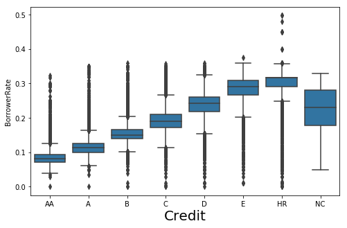

```python
plt.figure(figsize=[8,5])
sns.boxplot(data=loan_df_copy, x='Credit', y='BorrowerRate', color=bc)
plt.xlabel('Credit', fontsize=20);
```

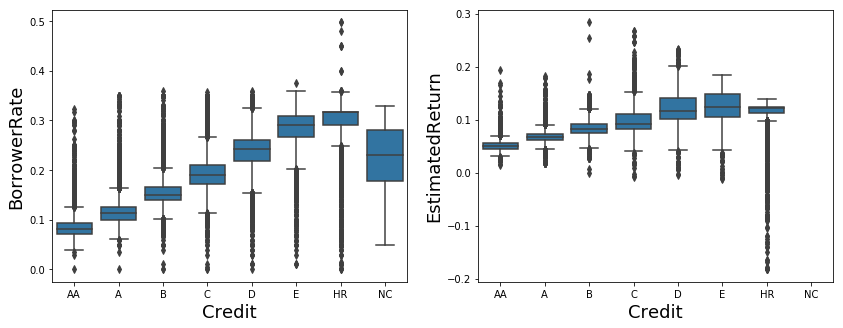

```python
fig, ax = plt.subplots(ncols = 2, figsize = [14,5])

num_var=['BorrowerRate','EstimatedReturn']
for i in range(2):
    var=num_var[i]

    sns.boxplot(data=loan_df_copy, x='Credit', y=var, ax=ax[i], color=bc)
    ax[i].set_xlabel('Credit',fontsize=18)
    ax[i].set_ylabel(var, fontsize=18);
```

### Homeowner and Employment Status Impact

- People who are not empolyed or not owning home are likely to get higher interest rate.
- 'non-employed' people stands out and receive much higher interest rate than employed peoplel whether full time, part time or self employed

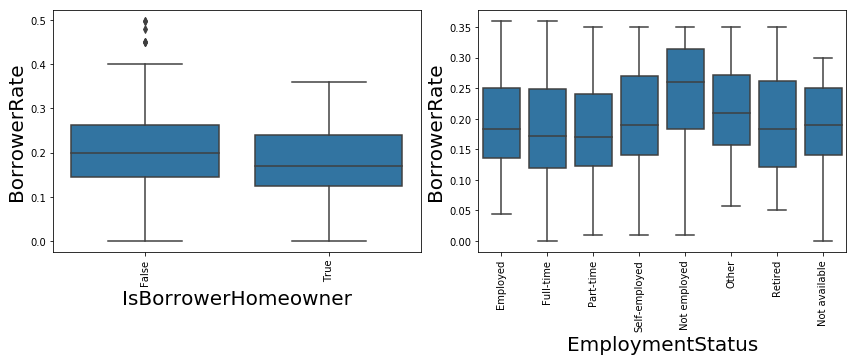

```python
fig, ax=plt.subplots(ncols=2, figsize=[12,5])

cat_columns_1=['IsBorrowerHomeowner','EmploymentStatus']

for i in range(2):
    var=cat_columns_1[i]
    sns.boxplot(data=loan_df_copy, x=var, y='BorrowerRate', ax=ax[i],color=bc)
    plt.xticks(rotation=90)
    plt.tight_layout()
    ax[i].set_xlabel(var,fontsize=20)
    ax[i].set_ylabel('BorrowerRate',fontsize=20)
    plt.setp(ax[i].get_xticklabels(), rotation=90)
```

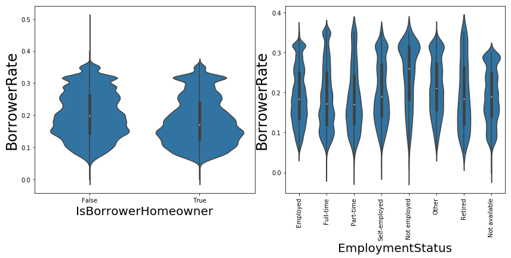

```python
fig, ax=plt.subplots(ncols=2, figsize=[12,6])

for i in range(2):
    var=cat_columns_1[i]
    sns.violinplot(data=loan_df_copy, x=var, y='BorrowerRate', ax=ax[i],color=bc)
    plt.xticks(rotation=90)
    plt.tight_layout()
    ax[i].set_xlabel(var,fontsize=20)
    ax[i].set_ylabel('BorrowerRate',fontsize=24)
```

### Credit & Homeowner Status Impact

- When applicant have higher credit rating than C , better grade, more homeowners tend to receive better interest rate. Once their credit rating is worse than C, more homeowners are likely getting higher interest rate.
- Once their rating is lower than C, being a homeowner does not differentiate their loan amount. It is also interesting to note their loan amount is quite small than 5000 for bad rating applicant.

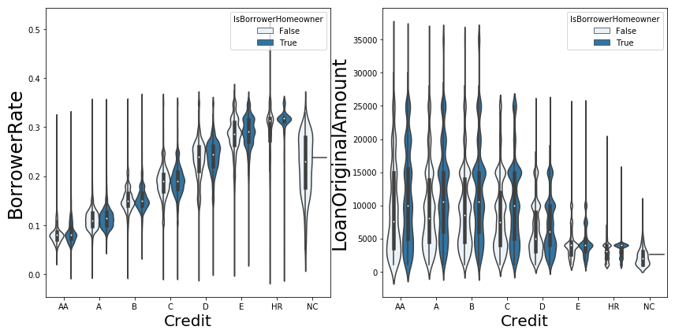

```python
fig, ax=plt.subplots(ncols=2, figsize=[12,6])
columns2=['BorrowerRate','LoanOriginalAmount']
for i in range(2):
    var=columns2[i]
    sns.violinplot(data=loan_df_copy, x='Credit', y=var, hue='IsBorrowerHomeowner',ax=ax[i],color=bc)

    plt.tight_layout()
    ax[i].set_xlabel('Credit',fontsize=20)
    ax[i].set_ylabel(var,fontsize=24);
```

# Characteristics of Bad Loans

### Loan Term Impact

- For larger loan amount, people are likely to pay it off with longer term.
- However, there is no specific pattern observed for good /bad loan vs different term, loan amount.

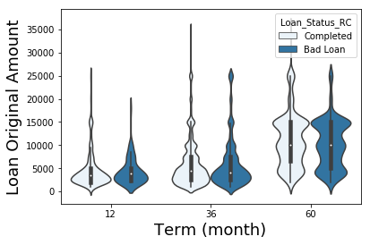

```python
sns.violinplot(data=loan_df_status,x="Term", y="LoanOriginalAmount", hue='Loan_Status_RC', color=bc)
plt.xlabel('Term (month)', fontsize=18)
plt.ylabel('Loan Original Amount', fontsize=18);
```

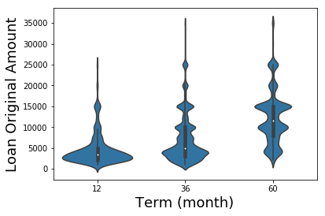

```python
sns.violinplot(data=loan_df_copy, x='Term', y='LoanOriginalAmount', color=bc)
plt.xlabel('Term (month)', fontsize=18)
plt.ylabel('Loan Original Amount', fontsize=18);
```

### Income Range Impact

- Higher income people is likely to apply for higher loan amount. There are more applicants likely to be bad loan with high income and large loan amount

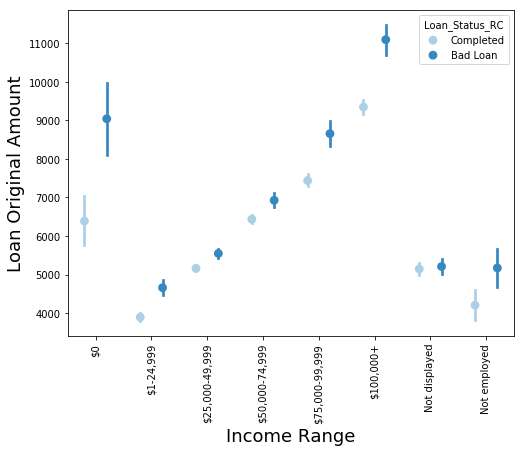

```python
plt.figure(figsize=[8,6])
sns.pointplot(data=loan_df_status, x='IncomeRange', y='LoanOriginalAmount',hue='Loan_Status_RC',palette = 'Blues', linestyles = '', dodge = 0.4)
plt.xticks(rotation=90)
plt.xlabel('Income Range', fontsize=18)
plt.ylabel('Loan Original Amount', fontsize=18);
```

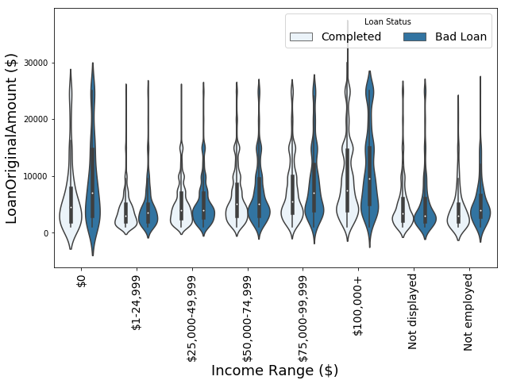

```python
plt.figure(figsize=[10,6])
sns.violinplot(data=loan_df_status, x='IncomeRange', y='LoanOriginalAmount',hue='Loan_Status_RC',color=bc)
plt.xticks(rotation=90,fontsize=14)
plt.legend(title='Loan Status', fontsize=14, ncol=2)
plt.xlabel('Income Range ($)', fontsize=18)
plt.ylabel('LoanOriginalAmount ($)', fontsize=18);
```

### Loan Category Impact

Although debt consolidation is most popular loan type. However, green loans seems having highest bad loan rate

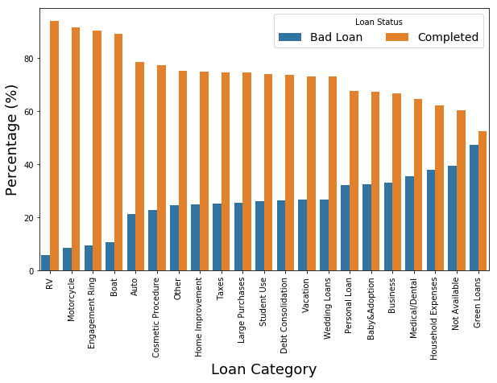

```python
plt.figure(figsize=[10,6])
category_counts=(loan_df_status.groupby('ListingCategory')['Loan_Status_RC'].value_counts(normalize=True)
                 .rename('Percentage')
                 .mul(100)
                 .reset_index()
                 .sort_values('Percentage'))
sns.barplot(x='ListingCategory', y='Percentage', hue='Loan_Status_RC', data=category_counts)
plt.xticks(rotation=90)
plt.legend(title='Loan Status', fontsize=14, ncol=2)
plt.xlabel('Loan Category', fontsize=18)
plt.ylabel('Percentage (%)', fontsize=18);
```